# biological data preperation

# checking data for NA’s

The presence points have a lot of NAs in the env. correlates. I want to:

-ID and remove rows where all values == NA -ID observations with no depth data that are missing surface values (will need to be removed) -ID observations with depth data but are missing some surface and/or depth values

how many rows(observations do you have)

```r
nrow(data_aea) # there are 11516 rows
```

[output not shown]

check for no rows (observations) with NAs

```r
presence_noNAcount <- sum(!complete.cases(data_aea)) #this just counts the number of rows that contain NA values
presence_noNAcount
```

```
[1] 4687
```

I have 4687 observations that contain NAs

1. find ones that have no env. data at all. these will need to be removed straight off.

There are 11516 rows in the original presence-point dataset

find the column numbers that correspond to the env. data (use fastmatch package as is quicker)

```r
fmatch("chl_surface", names(data_aea)) #28
```

```
[1] 28
```

```r
fmatch("chl_depth", names(data_aea)) #29
```

```
[1] 29
```

```r
fmatch("mlp_surface", names(data_aea)) #30
```

```
[1] 30
```

```r
fmatch("o2_surface", names(data_aea)) #31
```

```
[1] 31
```

```r
fmatch("o2_depth", names(data_aea)) #32
```

```
[1] 32
```

```r
fmatch("salinity_surface", names(data_aea)) #33
```

```
[1] 33
```

```r
fmatch("salinity_depth", names(data_aea)) #34
```

```
[1] 34
```

```r
fmatch("ssh_surface", names(data_aea)) #35
```

```
[1] 35
```

```r
fmatch("temp_surface", names(data_aea)) #36
```

```
[1] 36
```

```r
fmatch("temp_depth", names(data_aea)) #37
```

```
[1] 37
```

ok so the env. data i am intersted in is in cols 28:37

Out of curiosoity, map the location of these points. Note the difference between this and the code below is the addition of ! on rowSums

```r
presence_novals <- data_aea[!rowSums(is.na(data_aea[ , 28:37])) !=10, ] #4:13 represent the columns w/ env. data, 10 is the number of columns to check (4 to 13 inclusive)
write.csv(presence_novals, "../output/bio/presence_points_without_envdata.csv", row.names = FALSE)
nrow(presence_novals) #just to check it has mapped
```

```
[1] 123
```

So I had 123 rows without any env. data (11516 - 11393).

plot

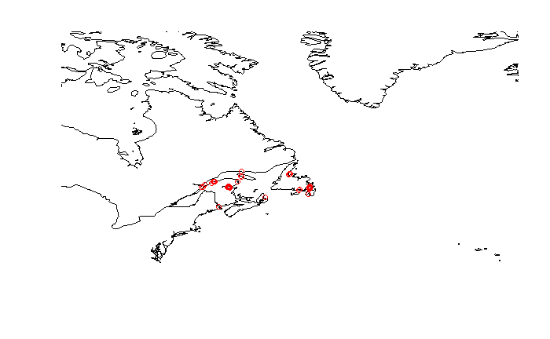

```r
map <- getMap(resolution = "low") #creates an object called map at low resoultion
plot(map, xlim = c(-70, -43), ylim =c(38,70), asp = 1) #the x and y lim are the long-lat bounds of the map
points(presence_novals$decimalLongitude, presence_novals$decimalLatitude, col = "red") #this adds points to the mapet", xlab = "Longitude", ylab = "Latitude")
```

Ok so they are along the coast, so the points probably fell outside the boxes (confirmed with closer inspection in ArcGIS).

Now remove the values

```r
data_aea <- data_aea[rowSums(is.na(data_aea[ , 28:37])) !=10, ] #4:13 represent the columns w/ env. data, 10 is the number of columns to check (4 to 13 inclusive)
write.csv(data_aea, "../output/bio/presence_nodata_rm")
nrow(data_aea)
```

```
[1] 11393
```

ok so the next step is to make sure that any of the data you have without a depth value does have all relevant surface values

maybe subset

```r
presence_nodepth = data_aea[is.na(data_aea$depth), ]
nrow(presence_nodepth) #1215 rows
```

```
[1] 1215
```

```r
head(presence_nodepth)
```

|  | cell_id | year | month | depthlayerno | id | decimalLatitude | decimalLongitude | datecollected | institutioncode | individualcount | depth | resname | originalscientificname | collectioncode | day | occurrence | nafo_zone | gear | longitude_meters | latitude_meters | amo_sample | amo_prev | amo_winter | depth_layer | bottom_depth | total_cell_obs | yymm_cell_obs | chl_surface | chl_depth | … |
| --- | --- | --- | --- | --- | --- | --- | --- | --- | --- | --- | --- | --- | --- | --- | --- | --- | --- | --- | --- | --- | --- | --- | --- | --- | --- | --- | --- | --- | --- | --- |
| 79 | 1947 | 2005 | 7 | NA | 386209674 | 58.4630 | -61.7230 | 2005-07-30 12:00:00+02 | DFOCENARC | xx | NA | DFO Central and Arctic Multi-species Stock Assessment Surveys | Mallotus villosus | DFOSurvey_Modified Standard (14") Campelen | 30 | 1 | 2G | bottom_trawl_campelen_14 | -99163.92 | 2046781 | 0.447 | 0.327 | 0.2143333 | NA | -167 | 1 | 1 | 0.2271005 | NA | … |
| 86 | 2044 | 2006 | 7 | NA | 386214533 | 58.0570 | -60.4750 | 2006-07-25 12:00:00+02 | DFOCENARC | xx | NA | DFO Central and Arctic Multi-species Stock Assessment Surveys | Mallotus villosus | DFOSurvey_Modified Standard (14") Campelen | 25 | 1 | 2G | bottom_trawl_campelen_14 | -27664.66 | 1999759 | 0.374 | 0.333 | 0.1410000 | NA | -187 | 1 | 1 | 0.5592623 | NA | … |
| 747 | 3098 | 2012 | 8 | NA | 385803819 | 52.2233 | -55.4798 | 2012-08-07 12:00:00+02 | DFOQC | xx | NA | DFO Quebec Region Multispecies bottom trawl surveys | Mallotus villosus | RELEVES_RECHERCHE | 7 | 1 | 4R | bottom_trawl_campelen_1800 | 307162.12 | 1354189 | 0.431 | 0.375 | 0.1533333 | NA | -137 | 3 | 1 | 0.2391456 | NA | … |
| 835 | 3134 | 2005 | 8 | NA | 385805825 | 52.1025 | -55.5385 | 2005-08-10 12:00:00+02 | DFOQC | xx | NA | DFO Quebec Region Multispecies bottom trawl surveys | Mallotus villosus | RELEVES_RECHERCHE | 10 | 1 | 4R | bottom_trawl_campelen_1800 | 304075.47 | 1340447 | 0.440 | 0.447 | 0.2143333 | NA | -110 | 11 | 2 | 0.2127260 | NA | … |
| 837 | 3134 | 2006 | 8 | NA | 385792481 | 51.9930 | -55.6090 | 2006-08-11 12:00:00+02 | DFOQC | xx | NA | DFO Quebec Region Multispecies bottom trawl surveys | Mallotus villosus | RELEVES_RECHERCHE | 11 | 1 | 4R | bottom_trawl_campelen_1800 | 300076.85 | 1327918 | 0.401 | 0.374 | 0.1410000 | NA | -116 | 11 | 2 | 0.2158516 | NA | … |
| 840 | 3134 | 2008 | 8 | NA | 385813809 | 52.1115 | -55.5268 | 2008-08-04 12:00:00+02 | DFOQC | xx | NA | DFO Quebec Region Multispecies bottom trawl surveys | Mallotus villosus | RELEVES_RECHERCHE | 4 | 1 | 4R | bottom_trawl_campelen_1800 | 304804.77 | 1341504 | 0.175 | 0.206 | 0.1863333 | NA | -107 | 11 | 4 | 0.1604485 | NA | … |

go through each value and see which are missing data

```r
presence_nodepth_nochl <- presence_nodepth[is.na(presence_nodepth$chl_surface), ]
nrow(presence_nodepth_nochl) #just to check it has mapped
```

```
[1] 0
```

```r
presence_nodepth_noo2 <- presence_nodepth[is.na(presence_nodepth$o2_surface), ]
nrow(presence_nodepth_noo2) #just to check it has mapped
```

```
[1] 0
```

```r
presence_nodepth_nosalinity <- presence_nodepth[is.na(presence_nodepth$salinity_surface), ]
nrow(presence_nodepth_nosalinity) #just to check it has mapped
```

```
[1] 0
```

```r
presence_nodepth_notemp <- presence_nodepth[is.na(presence_nodepth$temp_surface), ]
nrow(presence_nodepth_notemp) #just to check it has mapped
```

```
[1] 0
```

```r
presence_nodepth_nossh <- presence_nodepth[is.na(presence_nodepth$ssh_surface), ]
nrow(presence_nodepth_nossh) #just to check it has mapped
```

```
[1] 0
```

```r
presence_nodepth_nomlp <- presence_nodepth[is.na(presence_nodepth$mlp_surface), ]
nrow(presence_nodepth_nomlp) #just to check it has mapped
```

```
[1] 0
```

great! all of the values that have no depth data have surface data.

now on to the data which has depth data

```r
presence_wdepth = data_aea[!is.na(data_aea$depth), ]
nrow(presence_wdepth) #10178 rows
```

```
[1] 10178
```

```r
head(presence_wdepth)
```

|  | cell_id | year | month | depthlayerno | id | decimalLatitude | decimalLongitude | datecollected | institutioncode | individualcount | depth | resname | originalscientificname | collectioncode | day | occurrence | nafo_zone | gear | longitude_meters | latitude_meters | amo_sample | amo_prev | amo_winter | depth_layer | bottom_depth | total_cell_obs | yymm_cell_obs | chl_surface | chl_depth | … |
| --- | --- | --- | --- | --- | --- | --- | --- | --- | --- | --- | --- | --- | --- | --- | --- | --- | --- | --- | --- | --- | --- | --- | --- | --- | --- | --- | --- | --- | --- | --- |
| 1 | 1028 | 2007 | 10 | 34 | 386276184 | 61.882 | -68.600 | 2007-10-18 12:00:00+02 | DFOCENARC | xx | 262 | DFO Central and Arctic Multi-species Stock Assessment Surveys | Mallotus villosus | DFOSurvey_Modified Cosmos 2600 | 18 | 1 | HudsonStrait | bottom_trawl_cosmos_2600 | -444296.6 | 2460623 | 0.158 | 0.098 | 0.138 | 271.3564 | -269 | 1 | 1 | 0.5590227 | NA | … |
| 2 | 1029 | 2007 | 10 | 31 | 386276145 | 61.999 | -68.468 | 2007-10-18 12:00:00+02 | DFOCENARC | xx | 209 | DFO Central and Arctic Multi-species Stock Assessment Surveys | Mallotus villosus | DFOSurvey_Modified Cosmos 2600 | 18 | 1 | HudsonStrait | bottom_trawl_cosmos_2600 | -435849.1 | 2472891 | 0.158 | 0.098 | 0.138 | 199.7900 | -198 | 1 | 1 | 0.6236078 | 0.04989861 | … |
| 3 | 1030 | 2007 | 10 | 28 | 386276062 | 61.977 | -67.569 | 2007-10-17 12:00:00+02 | DFOCENARC | xx | 152 | DFO Central and Arctic Multi-species Stock Assessment Surveys | Mallotus villosus | DFOSurvey_Modified Cosmos 2600 | 17 | 1 | HudsonStrait | bottom_trawl_cosmos_2600 | -390065.1 | 2464892 | 0.158 | 0.098 | 0.138 | 147.4062 | -179 | 2 | 1 | 0.6505818 | 0.09880352 | … |
| 4 | 1030 | 2014 | 8 | 30 | 386263391 | 61.953 | -67.657 | 2014-08-30 12:00:00+02 | DFOCENARC | xx | 175 | DFO Central and Arctic Multi-species Stock Assessment Surveys | Mallotus villosus | DFOSurvey_Modified Modified (21") Campelen | 30 | 1 | HudsonStrait | bottom_trawl_campelen_21 | -394889.5 | 2462708 | 0.335 | 0.222 | 0.128 | 180.5499 | -182 | 2 | 1 | 0.2168258 | 0.07601523 | … |
| 5 | 1035 | 2011 | 8 | 33 | 386247163 | 62.045 | -64.171 | 2011-08-19 12:00:00+02 | DFOCENARC | xx | 244 | DFO Central and Arctic Multi-species Stock Assessment Surveys | Mallotus villosus | DFOSurvey_Modified Modified (21") Campelen | 19 | 1 | 0B | bottom_trawl_campelen_21 | -214790.3 | 2457259 | 0.147 | 0.092 | 0.100 | 244.8906 | -231 | 1 | 1 | 0.3032110 | 0.05210002 | … |
| 6 | 1039 | 2014 | 10 | 39 | 386301912 | 62.053 | -62.296 | 2014-10-14 12:00:00+02 | DFOCENARC | xx | 443 | DFO Central and Arctic Multi-species Stock Assessment Surveys | Mallotus villosus | DFOSurvey_Modified Alfredo-03 | 14 | 1 | 0B | bottom_trawl_alfredo_03 | -118257.1 | 2453515 | 0.292 | 0.310 | 0.128 | 457.6256 | -430 | 1 | 1 | 0.6282594 | 0.02792203 | … |

go through each value and see which are missing data. First the surface values

```r
presence_wdepth_nochl <- presence_wdepth[is.na(presence_wdepth$chl_surface), ]
nrow(presence_wdepth_nochl) #just to check it has mapped
```

```
[1] 0
```

```r
presence_wdepth_noo2 <- presence_wdepth[is.na(presence_wdepth$o2_surface), ]
nrow(presence_wdepth_noo2) #just to check it has mapped
```

```
[1] 0
```

```r
presence_wdepth_nosalinity <- presence_wdepth[is.na(presence_wdepth$salinity_surface), ]
nrow(presence_wdepth_nosalinity) #just to check it has mapped
```

```
[1] 0
```

```r
presence_wdepth_notemp <- presence_wdepth[is.na(presence_wdepth$temp_surface), ]
nrow(presence_wdepth_notemp) #just to check it has mapped
```

```
[1] 0
```

```r
presence_wdepth_nossh <- presence_wdepth[is.na(presence_wdepth$ssh_surface), ]
nrow(presence_wdepth_nossh) #just to check it has mapped
```

```
[1] 0
```

```r
presence_wdepth_nomlp <- presence_wdepth[is.na(presence_wdepth$mlp_surface), ]
nrow(presence_wdepth_nomlp) #just to check it has mapped
```

```
[1] 0
```

Great! All have surface values. now to the depth values

```r
presence_wdepth_nochl <- presence_wdepth[is.na(presence_wdepth$chl_depth), ]
nrow(presence_wdepth_nochl) #just to check it has mapped
```

```
[1] 2394
```

```r
presence_wdepth_noo2 <- presence_wdepth[is.na(presence_wdepth$o2_depth), ]
nrow(presence_wdepth_noo2) #just to check it has mapped
```

```
[1] 2394
```

```r
presence_wdepth_nosalinity <- presence_wdepth[is.na(presence_wdepth$salinity_depth), ]
nrow(presence_wdepth_nosalinity) #just to check it has mapped
```

```
[1] 3109
```

```r
presence_wdepth_notemp <- presence_wdepth[is.na(presence_wdepth$temp_depth), ]
nrow(presence_wdepth_notemp) #just to check it has mapped
```

```
[1] 3109
```

damn… so

chl_depth = 2394 missing values o2_depth = 2394 missing values salinity_depth = 3109 missing values temp_depth = 3109 missing values

This is interesting… chl and o2 are missing the same number of points - they come from the biomer dataset; salinity and temp come from glorys and have the same number of points.

I wonder how many of these points represent the same lat-long-depth… need to subset where chl_depth OR o2_depth OR salinity_depth OR temp_depth == NA These columns are not together

```r
presence_wdepth2 <-  presence_wdepth[!complete.cases(presence_wdepth[28:37]), ]
nrow(presence_wdepth2) #3349
```

```
[1] 3325
```

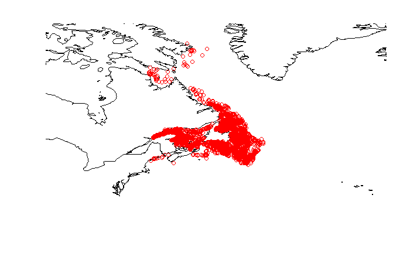

```r
map <- getMap(resolution = "low") #creates an object called map at low resoultion
plot(map, xlim = c(-70, -43), ylim =c(38,70), asp = 1) #the x and y lim are the long-lat bounds of the map
points(presence_wdepth2$decimalLongitude, presence_wdepth2$decimalLatitude, col = "red") #this adds points to the mapet", xlab = "Longitude", ylab = "Latitude")
```

hmm everywhere…

Is there a particular time-slice that the values appear in?

```r
npresence_wdepth2mmyy <- with(presence_wdepth2, table(year, month))
npresence_wdepth2mmyy
```

```
      month
year    1  3  4  5  6  7  8  9 10 11 12
  1998  0  0 23 30 29  0  0 19 25 80  3
  1999  0  2 26 17 43  2  0 36  4 58 18
  2000  0  1 18 13 22  0  0 37 11 68 21
  2001  0  2 41 26 28  2  0 23  8 22 68
  2002  0  0 34 20 17  0  0 36 11 25 42
  2003 19  1 35 27 33  2  0 23  8 12 40
  2004 51  0 24 25 29  1 58 47 13 32 46
  2005  7  0  9 28 21 10 71 53  7 59 18
  2006 22  5 10  3 25  3 75 46 18 30 37
  2007  0  2 28 16 15 15 71 36 13 21 38
  2008  0  4 18 21 21  8 77 37  3 39 23
  2009  0  0 36 39 10  0  0 32 14 53 26
  2010  0  2 23 19 13  0  2 39 17 52 33
  2011  0  0 26 20 14  0  5 35 21 31 18
  2012  0  0  0  0  0  2  1 39  0  0  0
  2013  0  0  0  0  0  2  2 37  4  1  0
  2014  0  0  0  0  0  1  4 47  0  0  0
  2015  0  0  0  0  0  0  2  2  0  1  0
```

hmm there is a lot… how does this compare to the original dataset

```r
data_aeammyy <- with(data_aea, table(year, month))
data_aeammyy
```

```
      month
year     1   2   3   4   5   6   7   8   9  10  11  12
  1998   0   0   0  63  83 146  21   0  48  79 206  11
  1999   0   0  48  45  68 165  26   0  89  11 155  60
  2000   0   0  42  42  65 125  33   0  98  35 185  80
  2001   0   6  24  75  84 105  15   0  50  25  90 167
  2002   0   0  35  77  86 109  17   0 110  40  75 107
  2003  60   0  23  75 100 136  19   0  43  37  54 113
  2004 129   0   0  57  87 136  26 163 101  29 113 120
  2005  19   4  34  22  71 111  53 226 109  48 158  46
  2006  54   1  59  22   5 140  26 243  79  71 112  85
  2007   0   0  20  55  54 104  78 237  85  40 104  91
  2008   0   0  31  38  84 131  33 251  77  27 137  65
  2009   0   0  11  71 154  58   9 121  80  37 164  52
  2010   0   0  19  42  72 125  25 118 100  66 157  63
  2011   0   0   0  60 103 107  11 151  72  65 106  55
  2012   0   0   0   0   0   0   8 158  85   0   0   0
  2013   0   0   0   0   0   0  27 132  68   7   2   0
  2014   0   0   0   0   0   0   1  11 115   3   0   0
  2015   0   0   0   0   0   0   0   4   8   0   3   0
```

First you need to put the observations (data_aea) into a spatialpointsdataframe.

```r
fmatch("longitude_meters", names(data_aea)) #28
```

```
[1] 19
```

```r
fmatch("latitude_meters", names(data_aea)) #28
```

```
[1] 20
```

```r
library(sp)
xy <- data_aea[ ,c(19,20)] # This is to tell R where the coordinates are (in column 19 and 20). Note that the column order needs to be longitude, latitude
data_aea_sp <- SpatialPointsDataFrame(coords = xy, data = data_aea, proj4string = CRS("+proj=aea +lat_1=50 +lat_2=70 +lat_0=40 +lon_0=-60 +x_0=0 +y_0=0 +ellps=GRS80 +datum=NAD83 +units=m +no_defs")) # The CRS is used here is for the albers equal area projection.
```

```r
netcdf_list <- list.files("../data/env/renetcdf", pattern = '*.nc', full.names = TRUE) #true means the full path is included
no_netcdf <- length(netcdf_list) #for the loop - need to know how many files to cycle through
netcdf_name <- list.files("../data/env/renetcdf", pattern = '*.nc', full.names = FALSE) #false means the path is not includedCores
library (ncdf4)
library(sp)
library(rgdal)
for (i in 1:no_netcdf) {
  library(raster)
  print(netcdf_name[i]) #this just prints the name of the netCDF R is working one
  brkyr <- as.integer(sapply(strsplit(netcdf_name[i], "_"), "[[", 1)) # extracting the first part of the netcdf filename (which is the year)
  brkmth <- as.integer(sapply(strsplit(netcdf_name[i], "_"), "[[", 2)) # extracting the second part of the netcdf filename (which is the month)
  brkvar <- (sapply(strsplit(netcdf_name[i], "_"), "[[", 3)) # extracting the third part of the netcdf (inc.nc)
  temp_brick <- brick(netcdf_list[i], lvar = 4)
  temp_brick <- projectRaster(temp_brick, aea)
    for (j in 1:nrow(data_aea_sp)) {
      de <- data_aea_sp$depthlayerno[[j]]  # a variable for the observation depth layer
      yr <- (data_aea_sp$year[j])  # a variable for the observation year
      mth <- (data_aea_sp$month[j])  # a variable for the observation month
          if (brkyr == yr & brkmth == mth & brkvar == "temp.nc"){
              if (is.na(de)){
                data_aea_sp$temp_depth[j] <- NA
              } else
                data_aea_sp$temp_depth[j] <- extract(x=temp_brick[[de]], y = data_aea_sp[j, ])
          } else if (brkyr == yr & brkmth == mth & brkvar == "salinity.nc") {
              if (is.na(de)){
                data_aea_sp$salinity_depth[j] <- NA
              } else
                data_aea_sp$salinity_depth[j] <- extract(x=temp_brick[[de]], y = data_aea_sp[j, ])
          } else if (brkyr == yr & brkmth == mth & brkvar == "chl.nc") {
              if (is.na(de)){
                data_aea_sp$chl_depth[j] <- NA
              } else
                data_aea_sp$chl_depth[j] <- extract(x=temp_brick[[de]], y = data_aea_sp[j, ])
          } else if (brkyr == yr & brkmth == mth & brkvar == "o2.nc") {
              if (is.na(de)){
                data_aea_sp$o2_depth[j] <- NA
              }
          }

    }
}
testdata_aea <- as.data.frame(data_aea_sp)
```

lets see if that made any difference… nope ok so it wasnt that i was missing the files

now on to the data which has depth data

```r
presence_wdepthv2 = data_aea[!is.na(data_aea$depth), ]
nrow(presence_wdepthv2) #10178 rows - same as before
```

```
[1] 10178
```

```r
head(presence_wdepthv2)
```

|  | cell_id | year | month | depthlayerno | id | decimalLatitude | decimalLongitude | datecollected | institutioncode | individualcount | depth | resname | originalscientificname | collectioncode | day | occurrence | nafo_zone | gear | longitude_meters | latitude_meters | amo_sample | amo_prev | amo_winter | depth_layer | bottom_depth | total_cell_obs | yymm_cell_obs | chl_surface | chl_depth | … |
| --- | --- | --- | --- | --- | --- | --- | --- | --- | --- | --- | --- | --- | --- | --- | --- | --- | --- | --- | --- | --- | --- | --- | --- | --- | --- | --- | --- | --- | --- | --- |
| 1 | 1028 | 2007 | 10 | 34 | 386276184 | 61.882 | -68.600 | 2007-10-18 12:00:00+02 | DFOCENARC | xx | 262 | DFO Central and Arctic Multi-species Stock Assessment Surveys | Mallotus villosus | DFOSurvey_Modified Cosmos 2600 | 18 | 1 | HudsonStrait | bottom_trawl_cosmos_2600 | -444296.6 | 2460623 | 0.158 | 0.098 | 0.138 | 271.3564 | -269 | 1 | 1 | 0.5590227 | NA | … |
| 2 | 1029 | 2007 | 10 | 31 | 386276145 | 61.999 | -68.468 | 2007-10-18 12:00:00+02 | DFOCENARC | xx | 209 | DFO Central and Arctic Multi-species Stock Assessment Surveys | Mallotus villosus | DFOSurvey_Modified Cosmos 2600 | 18 | 1 | HudsonStrait | bottom_trawl_cosmos_2600 | -435849.1 | 2472891 | 0.158 | 0.098 | 0.138 | 199.7900 | -198 | 1 | 1 | 0.6236078 | 0.04989861 | … |
| 3 | 1030 | 2007 | 10 | 28 | 386276062 | 61.977 | -67.569 | 2007-10-17 12:00:00+02 | DFOCENARC | xx | 152 | DFO Central and Arctic Multi-species Stock Assessment Surveys | Mallotus villosus | DFOSurvey_Modified Cosmos 2600 | 17 | 1 | HudsonStrait | bottom_trawl_cosmos_2600 | -390065.1 | 2464892 | 0.158 | 0.098 | 0.138 | 147.4062 | -179 | 2 | 1 | 0.6505818 | 0.09880352 | … |
| 4 | 1030 | 2014 | 8 | 30 | 386263391 | 61.953 | -67.657 | 2014-08-30 12:00:00+02 | DFOCENARC | xx | 175 | DFO Central and Arctic Multi-species Stock Assessment Surveys | Mallotus villosus | DFOSurvey_Modified Modified (21") Campelen | 30 | 1 | HudsonStrait | bottom_trawl_campelen_21 | -394889.5 | 2462708 | 0.335 | 0.222 | 0.128 | 180.5499 | -182 | 2 | 1 | 0.2168258 | 0.07601523 | … |
| 5 | 1035 | 2011 | 8 | 33 | 386247163 | 62.045 | -64.171 | 2011-08-19 12:00:00+02 | DFOCENARC | xx | 244 | DFO Central and Arctic Multi-species Stock Assessment Surveys | Mallotus villosus | DFOSurvey_Modified Modified (21") Campelen | 19 | 1 | 0B | bottom_trawl_campelen_21 | -214790.3 | 2457259 | 0.147 | 0.092 | 0.100 | 244.8906 | -231 | 1 | 1 | 0.3032110 | 0.05210002 | … |
| 6 | 1039 | 2014 | 10 | 39 | 386301912 | 62.053 | -62.296 | 2014-10-14 12:00:00+02 | DFOCENARC | xx | 443 | DFO Central and Arctic Multi-species Stock Assessment Surveys | Mallotus villosus | DFOSurvey_Modified Alfredo-03 | 14 | 1 | 0B | bottom_trawl_alfredo_03 | -118257.1 | 2453515 | 0.292 | 0.310 | 0.128 | 457.6256 | -430 | 1 | 1 | 0.6282594 | 0.02792203 | … |

```r
npresence_wdepth2mmyy2 <- with(presence_wdepthv2, table(year, month))
npresence_wdepth2mmyy2
```

```
      month
year     1   2   3   4   5   6   7   8   9  10  11  12
  1998   0   0   0  63  83 143  21   0  48  79 206  11
  1999   0   0  48  45  68 165  26   0  89  11 155  60
  2000   0   0  42  42  65 125  33   0  98  35 185  80
  2001   0   6  24  75  84 105  15   0  50  25  90 167
  2002   0   0  35  77  86 109  17   0 110  40  75 107
  2003  60   0  23  75 100 136  19   0  43  37  54 113
  2004 129   0   0  57  87 136  26  82  95  29 113 120
  2005  19   4  34  22  71 111  52 118 109  48 158  46
  2006  54   1  59  22   5 140  25 125  79  71 112  85
  2007   0   0  20  55  54 103  76 124  85  40 104  91
  2008   0   0  31  38  83 131  21 132  77  27 137  65
  2009   0   0  11  71 154  56   9   0  78  37 164  52
  2010   0   0  19  42  71 125  25  10 100  66 157  63
  2011   0   0   0  60 103 107  11  12  72  65 106  55
  2012   0   0   0   0   0   0   8  10  85   0   0   0
  2013   0   0   0   0   0   0  27   5  68   7   2   0
  2014   0   0   0   0   0   0   1  10 115   3   0   0
  2015   0   0   0   0   0   0   0   4   8   0   3   0
```

no change…

ok is there a depth layer in particular that is an issue? maybe some are missing a depthlayerno?

```r
presence_wdepth_nolayerno <- presence_wdepth2[is.na(presence_wdepth2$depthlayerno), ]
nrow(presence_wdepth_nolayerno) #0
```

```
[1] 0
```

```r
head(presence_wdepth_nolayerno)
```

| cell_id | year | month | depthlayerno | id | decimalLatitude | decimalLongitude | datecollected | institutioncode | individualcount | depth | resname | originalscientificname | collectioncode | day | occurrence | nafo_zone | gear | longitude_meters | latitude_meters | amo_sample | amo_prev | amo_winter | depth_layer | bottom_depth | total_cell_obs | yymm_cell_obs | chl_surface | chl_depth | mlp_surface | … |
| --- | --- | --- | --- | --- | --- | --- | --- | --- | --- | --- | --- | --- | --- | --- | --- | --- | --- | --- | --- | --- | --- | --- | --- | --- | --- | --- | --- | --- | --- | --- |

ok so all have a depthlayerno attached

check for count of each depth layer

```r
whichdepths <- unique(presence_wdepth2$depthlayerno) #makes a variable of institutions
whichdepthsordered <- sort(whichdepths) #just puts the list in
whichdepthsordered
```

```
 [1] 10 14 15 16 17 18 19 20 21 22 23 24 25 26 27 28 29 30 31 32 33 34 35 36 37 38 39 40 41 42 43 44 45 46
```

quite a wide group… look at frequency

```r
whichdepthscount <- count(presence_wdepth2, "depthlayerno")
whichdepthscount
```

| depthlayerno | freq |
| --- | --- |
| 10 | 1 |
| 14 | 2 |
| 15 | 3 |
| 16 | 9 |
| 17 | 12 |
| 18 | 26 |
| 19 | 31 |
| 20 | 100 |
| 21 | 202 |
| 22 | 135 |

[output cut: 24 more lines]

very variable…

How many rows are missing all depth data?

```r
presence_wdepthonly <- subset(presence_wdepth2, select = -c(mlp_surface, ssh_surface, temp_surface, salinity_surface, o2_surface, chl_surface))
head(presence_wdepthonly)
```

|  | cell_id | year | month | depthlayerno | id | decimalLatitude | decimalLongitude | datecollected | institutioncode | individualcount | depth | resname | originalscientificname | collectioncode | day | occurrence | nafo_zone | gear | longitude_meters | latitude_meters | amo_sample | amo_prev | amo_winter | depth_layer | bottom_depth | total_cell_obs | yymm_cell_obs | chl_depth | o2_depth | … |
| --- | --- | --- | --- | --- | --- | --- | --- | --- | --- | --- | --- | --- | --- | --- | --- | --- | --- | --- | --- | --- | --- | --- | --- | --- | --- | --- | --- | --- | --- | --- |
| 1 | 1028 | 2007 | 10 | 34 | 386276184 | 61.882 | -68.600 | 2007-10-18 12:00:00+02 | DFOCENARC | xx | 262 | DFO Central and Arctic Multi-species Stock Assessment Surveys | Mallotus villosus | DFOSurvey_Modified Cosmos 2600 | 18 | 1 | HudsonStrait | bottom_trawl_cosmos_2600 | -444296.6 | 2460623 | 0.158 | 0.098 | 0.13800000 | 271.3564 | -269 | 1 | 1 | NA | NA | … |
| 7 | 1068 | 2007 | 10 | 33 | 386276649 | 61.540 | -69.962 | 2007-10-19 12:00:00+02 | DFOCENARC | xx | 242 | DFO Central and Arctic Multi-species Stock Assessment Surveys | Mallotus villosus | DFOSurvey_Modified Cosmos 2600 | 19 | 1 | HudsonStrait | bottom_trawl_cosmos_2600 | -519897.9 | 2432065 | 0.158 | 0.098 | 0.13800000 | 244.8906 | -241 | 1 | 1 | NA | NA | … |
| 8 | 1069 | 2015 | 8 | 35 | 386270555 | 61.621 | -69.656 | 2015-08-28 12:00:00+02 | DFOCENARC | xx | 289 | DFO Central and Arctic Multi-species Stock Assessment Surveys | Mallotus villosus | DFOSurvey_Modified Modified (21") Campelen | 28 | 1 | HudsonStrait | bottom_trawl_campelen_21 | -502727.3 | 2438804 | 0.178 | 0.132 | -0.02300000 | 300.8875 | -256 | 1 | 1 | NA | NA | … |
| 9 | 1114 | 2013 | 10 | 33 | 386298389 | 61.450 | -69.841 | 2013-10-04 12:00:00+02 | DFOCENARC | xx | 234 | DFO Central and Arctic Multi-species Stock Assessment Surveys | Mallotus villosus | DFOSurvey_Modified Cosmos 2600 | 4 | 1 | HudsonStrait | bottom_trawl_cosmos_2600 | -515115.2 | 2421059 | 0.347 | 0.255 | -0.03533333 | 244.8906 | -242 | 1 | 1 | NA | NA | … |
| 13 | 1122 | 2009 | 10 | 33 | 386284041 | 61.647 | -66.234 | 2009-10-14 12:00:00+02 | DFOCENARC | xx | 247 | DFO Central and Arctic Multi-species Stock Assessment Surveys | Mallotus villosus | DFOSurvey_Modified Cosmos 2600 | 14 | 1 | HudsonStrait | bottom_trawl_cosmos_2600 | -324945.7 | 2420640 | 0.165 | 0.057 | 0.08966667 | 244.8906 | -231 | 1 | 1 | NA | NA | … |
| 14 | 1164 | 2013 | 10 | 31 | 386298350 | 61.135 | -69.956 | 2013-10-04 12:00:00+02 | DFOCENARC | xx | 190 | DFO Central and Arctic Multi-species Stock Assessment Surveys | Mallotus villosus | DFOSurvey_Modified Cosmos 2600 | 4 | 1 | HudsonStrait | bottom_trawl_cosmos_2600 | -526354.0 | 2386695 | 0.347 | 0.255 | -0.03533333 | 199.7900 | -161 | 1 | 1 | NA | NA | … |

get the col numbers for the depth data

```r
fmatch("chl_depth", names(presence_wdepthonly)) #28
```

```
[1] 28
```

```r
fmatch("o2_depth", names(presence_wdepthonly)) #29
```

```
[1] 29
```

```r
fmatch("salinity_depth", names(presence_wdepthonly)) #30
```

```
[1] 30
```

```r
fmatch("temp_depth", names(presence_wdepthonly)) #31
```

```
[1] 31
```

now subset rows where all depth data is missing

```r
presence_wdepthonly_allmissing <-  presence_wdepthonly[(is.na(presence_wdepthonly$temp_depth)) & (is.na(presence_wdepthonly$o2_depth)) & (is.na(presence_wdepthonly$salinity_depth)) & (is.na(presence_wdepthonly$chl_depth)), ]
nrow(presence_wdepthonly_allmissing) #2178
```

```
[1] 2178
```

```r
head(presence_wdepthonly_allmissing)
```

|  | cell_id | year | month | depthlayerno | id | decimalLatitude | decimalLongitude | datecollected | institutioncode | individualcount | depth | resname | originalscientificname | collectioncode | day | occurrence | nafo_zone | gear | longitude_meters | latitude_meters | amo_sample | amo_prev | amo_winter | depth_layer | bottom_depth | total_cell_obs | yymm_cell_obs | chl_depth | o2_depth | … |
| --- | --- | --- | --- | --- | --- | --- | --- | --- | --- | --- | --- | --- | --- | --- | --- | --- | --- | --- | --- | --- | --- | --- | --- | --- | --- | --- | --- | --- | --- | --- |
| 1 | 1028 | 2007 | 10 | 34 | 386276184 | 61.882 | -68.600 | 2007-10-18 12:00:00+02 | DFOCENARC | xx | 262 | DFO Central and Arctic Multi-species Stock Assessment Surveys | Mallotus villosus | DFOSurvey_Modified Cosmos 2600 | 18 | 1 | HudsonStrait | bottom_trawl_cosmos_2600 | -444296.6 | 2460623 | 0.158 | 0.098 | 0.13800000 | 271.3564 | -269 | 1 | 1 | NA | NA | … |
| 7 | 1068 | 2007 | 10 | 33 | 386276649 | 61.540 | -69.962 | 2007-10-19 12:00:00+02 | DFOCENARC | xx | 242 | DFO Central and Arctic Multi-species Stock Assessment Surveys | Mallotus villosus | DFOSurvey_Modified Cosmos 2600 | 19 | 1 | HudsonStrait | bottom_trawl_cosmos_2600 | -519897.9 | 2432065 | 0.158 | 0.098 | 0.13800000 | 244.8906 | -241 | 1 | 1 | NA | NA | … |
| 8 | 1069 | 2015 | 8 | 35 | 386270555 | 61.621 | -69.656 | 2015-08-28 12:00:00+02 | DFOCENARC | xx | 289 | DFO Central and Arctic Multi-species Stock Assessment Surveys | Mallotus villosus | DFOSurvey_Modified Modified (21") Campelen | 28 | 1 | HudsonStrait | bottom_trawl_campelen_21 | -502727.3 | 2438804 | 0.178 | 0.132 | -0.02300000 | 300.8875 | -256 | 1 | 1 | NA | NA | … |
| 9 | 1114 | 2013 | 10 | 33 | 386298389 | 61.450 | -69.841 | 2013-10-04 12:00:00+02 | DFOCENARC | xx | 234 | DFO Central and Arctic Multi-species Stock Assessment Surveys | Mallotus villosus | DFOSurvey_Modified Cosmos 2600 | 4 | 1 | HudsonStrait | bottom_trawl_cosmos_2600 | -515115.2 | 2421059 | 0.347 | 0.255 | -0.03533333 | 244.8906 | -242 | 1 | 1 | NA | NA | … |
| 13 | 1122 | 2009 | 10 | 33 | 386284041 | 61.647 | -66.234 | 2009-10-14 12:00:00+02 | DFOCENARC | xx | 247 | DFO Central and Arctic Multi-species Stock Assessment Surveys | Mallotus villosus | DFOSurvey_Modified Cosmos 2600 | 14 | 1 | HudsonStrait | bottom_trawl_cosmos_2600 | -324945.7 | 2420640 | 0.165 | 0.057 | 0.08966667 | 244.8906 | -231 | 1 | 1 | NA | NA | … |
| 14 | 1164 | 2013 | 10 | 31 | 386298350 | 61.135 | -69.956 | 2013-10-04 12:00:00+02 | DFOCENARC | xx | 190 | DFO Central and Arctic Multi-species Stock Assessment Surveys | Mallotus villosus | DFOSurvey_Modified Cosmos 2600 | 4 | 1 | HudsonStrait | bottom_trawl_cosmos_2600 | -526354.0 | 2386695 | 0.347 | 0.255 | -0.03533333 | 199.7900 | -161 | 1 | 1 | NA | NA | … |

ok before going further, just rerun the loop again on all the data just to make sure there wasn’t some silly fail…

First you need to put the observations (data_aea) into a spatialpointsdataframe.

```r
library(sp)
xy <- data_aea[ ,c(19,20)] # This is to tell R where the coordinates are (in column 18 and 19). Note that the column order needs to be longitude, latitude
data_aea_sp <- SpatialPointsDataFrame(coords = xy, data = data_aea, proj4string = CRS("+proj=aea +lat_1=50 +lat_2=70 +lat_0=40 +lon_0=-60 +x_0=0 +y_0=0 +ellps=GRS80 +datum=NAD83 +units=m +no_defs")) # The CRS is used here is for the albers equal area projection.
```

```r
netcdf_list <- list.files("../data/env/netcdf", pattern = '*.nc', full.names = TRUE) #true means the full path is included
no_netcdf <- length(netcdf_list) #for the loop - need to know how many files to cycle through
netcdf_name <- list.files("../data/env/netcdf", pattern = '*.nc', full.names = FALSE) #false means the path is not includedCores
library (ncdf4)
library(sp)
library(rgdal)
for (i in 1:no_netcdf) {
  library(raster)
  print(netcdf_name[i]) #this just prints the name of the netCDF R is working one
  brkyr <- as.integer(sapply(strsplit(netcdf_name[i], "_"), "[[", 1)) # extracting the first part of the netcdf filename (which is the year)
  brkmth <- as.integer(sapply(strsplit(netcdf_name[i], "_"), "[[", 2)) # extracting the second part of the netcdf filename (which is the month)
  brkvar <- (sapply(strsplit(netcdf_name[i], "_"), "[[", 3)) # extracting the third part of the netcdf (inc.nc)
  temp_brick <- brick(netcdf_list[i], lvar = 4)
  temp_brick <- projectRaster(temp_brick, aea)
    for (j in 1:nrow(data_aea_sp)) {
      de <- data_aea_sp$depthlayerno[[j]]  # a variable for the observation depth layer
      yr <- (data_aea_sp$year[j])  # a variable for the observation year
      mth <- (data_aea_sp$month[j])  # a variable for the observation month
          if (brkyr == yr & brkmth == mth & brkvar == "temp.nc"){
              data_aea_sp$temp_surface[j] <- extract(x=temp_brick[[1]], y = data_aea_sp[j, ])
              if (is.na(de)){
                data_aea_sp$temp_depth[j] <- NA
              } else
                data_aea_sp$temp_depth[j] <- extract(x=temp_brick[[de]], y = data_aea_sp[j, ])
          } else if (brkyr == yr & brkmth == mth & brkvar == "salinity.nc") {
              data_aea_sp$salinity_surface[j] <- extract(x=temp_brick[[1]], y = data_aea_sp[j, ])
              if (is.na(de)){
                data_aea_sp$salinity_depth[j] <- NA
              } else
                data_aea_sp$salinity_depth[j] <- extract(x=temp_brick[[de]], y = data_aea_sp[j, ])
          } else if (brkyr == yr & brkmth == mth & brkvar == "chl.nc") {
              data_aea_sp$chl_surface[j] <- extract(x=temp_brick[[1]], y = data_aea_sp[j, ])
              if (is.na(de)){
                data_aea_sp$chl_depth[j] <- NA
              } else
                data_aea_sp$chl_depth[j] <- extract(x=temp_brick[[de]], y = data_aea_sp[j, ])
          } else if (brkyr == yr & brkmth == mth & brkvar == "o2.nc") {
              data_aea_sp$o2_surface[j] <- extract(x=temp_brick[[1]], y = data_aea_sp[j, ])
              if (is.na(de)){
                data_aea_sp$o2_depth[j] <- NA
              } else
                data_aea_sp$o2_depth[j] <- extract(x=temp_brick[[de]], y = data_aea_sp[j, ])
          } else if (brkyr == yr & brkmth == mth & brkvar == "mlp.nc") {
              data_aea_sp$mlp_surface[j] <- extract(x=temp_brick[[1]], y = data_aea_sp[j, ])
          } else if (brkyr == yr & brkmth == mth & brkvar == "ssh.nc") {
              data_aea_sp$ssh_surface[j] <- extract(x=temp_brick[[1]], y = data_aea_sp[j, ])

          }

    }
}
```

```
[1] "1998_01_chl.nc"
[1] "1998_01_mlp.nc"
```

```
no non-missing arguments to min; returning Infno non-missing arguments to max; returning -Inf
```

```
[1] "1998_01_o2.nc"
[1] "1998_01_salinity.nc"
[1] "1998_01_ssh.nc"
```

```
no non-missing arguments to min; returning Infno non-missing arguments to max; returning -Inf
```

```
[1] "1998_01_temp.nc"
[1] "1998_02_chl.nc"
```

see if it has made a difference

```r
presence_wdepthv3 = data_aea[!is.na(data_aea$depth), ]
nrow(presence_wdepthv3) #10178 rows - same as before whcih is good
```

```
[1] 10178
```

```r
head(presence_wdepthv3)
```

|  | cell_id | year | month | depthlayerno | id | decimalLatitude | decimalLongitude | datecollected | institutioncode | individualcount | depth | resname | originalscientificname | collectioncode | day | occurrence | nafo_zone | gear | longitude_meters | latitude_meters | amo_sample | amo_prev | amo_winter | depth_layer | bottom_depth | total_cell_obs | yymm_cell_obs | chl_surface | chl_depth | … |
| --- | --- | --- | --- | --- | --- | --- | --- | --- | --- | --- | --- | --- | --- | --- | --- | --- | --- | --- | --- | --- | --- | --- | --- | --- | --- | --- | --- | --- | --- | --- |
| 1 | 1028 | 2007 | 10 | 34 | 386276184 | 61.882 | -68.600 | 2007-10-18 12:00:00+02 | DFOCENARC | xx | 262 | DFO Central and Arctic Multi-species Stock Assessment Surveys | Mallotus villosus | DFOSurvey_Modified Cosmos 2600 | 18 | 1 | HudsonStrait | bottom_trawl_cosmos_2600 | -444296.6 | 2460623 | 0.158 | 0.098 | 0.138 | 271.3564 | -269 | 1 | 1 | 0.5590227 | NA | … |
| 2 | 1029 | 2007 | 10 | 31 | 386276145 | 61.999 | -68.468 | 2007-10-18 12:00:00+02 | DFOCENARC | xx | 209 | DFO Central and Arctic Multi-species Stock Assessment Surveys | Mallotus villosus | DFOSurvey_Modified Cosmos 2600 | 18 | 1 | HudsonStrait | bottom_trawl_cosmos_2600 | -435849.1 | 2472891 | 0.158 | 0.098 | 0.138 | 199.7900 | -198 | 1 | 1 | 0.6236078 | 0.04989861 | … |
| 3 | 1030 | 2007 | 10 | 28 | 386276062 | 61.977 | -67.569 | 2007-10-17 12:00:00+02 | DFOCENARC | xx | 152 | DFO Central and Arctic Multi-species Stock Assessment Surveys | Mallotus villosus | DFOSurvey_Modified Cosmos 2600 | 17 | 1 | HudsonStrait | bottom_trawl_cosmos_2600 | -390065.1 | 2464892 | 0.158 | 0.098 | 0.138 | 147.4062 | -179 | 2 | 1 | 0.6505818 | 0.09880352 | … |
| 4 | 1030 | 2014 | 8 | 30 | 386263391 | 61.953 | -67.657 | 2014-08-30 12:00:00+02 | DFOCENARC | xx | 175 | DFO Central and Arctic Multi-species Stock Assessment Surveys | Mallotus villosus | DFOSurvey_Modified Modified (21") Campelen | 30 | 1 | HudsonStrait | bottom_trawl_campelen_21 | -394889.5 | 2462708 | 0.335 | 0.222 | 0.128 | 180.5499 | -182 | 2 | 1 | 0.2168258 | 0.07601523 | … |
| 5 | 1035 | 2011 | 8 | 33 | 386247163 | 62.045 | -64.171 | 2011-08-19 12:00:00+02 | DFOCENARC | xx | 244 | DFO Central and Arctic Multi-species Stock Assessment Surveys | Mallotus villosus | DFOSurvey_Modified Modified (21") Campelen | 19 | 1 | 0B | bottom_trawl_campelen_21 | -214790.3 | 2457259 | 0.147 | 0.092 | 0.100 | 244.8906 | -231 | 1 | 1 | 0.3032110 | 0.05210002 | … |
| 6 | 1039 | 2014 | 10 | 39 | 386301912 | 62.053 | -62.296 | 2014-10-14 12:00:00+02 | DFOCENARC | xx | 443 | DFO Central and Arctic Multi-species Stock Assessment Surveys | Mallotus villosus | DFOSurvey_Modified Alfredo-03 | 14 | 1 | 0B | bottom_trawl_alfredo_03 | -118257.1 | 2453515 | 0.292 | 0.310 | 0.128 | 457.6256 | -430 | 1 | 1 | 0.6282594 | 0.02792203 | … |

```r
presence_wdepth_nochl3 <- presence_wdepthv3[is.na(presence_wdepthv3$chl_depth), ]
nrow(presence_wdepth_nochl3) #just to check it has mapped
```

```
[1] 2394
```

```r
presence_wdepth_noo23 <- presence_wdepthv3[is.na(presence_wdepthv3$o2_depth), ]
nrow(presence_wdepth_noo23) #just to check it has mapped
```

```
[1] 2394
```

```r
presence_wdepth_nosalinity3 <- presence_wdepthv3[is.na(presence_wdepthv3$salinity_depth), ]
nrow(presence_wdepth_nosalinity3) #just to check it has mapped
```

```
[1] 3109
```

```r
presence_wdepth_notemp3 <- presence_wdepthv3[is.na(presence_wdepthv3$temp_depth), ]
nrow(presence_wdepth_notemp3) #just to check it has mapped
```

```
[1] 3109
```

It used to be [1] 2394 [1] 2394 [1] 3109 [1] 3109 so no change.

ok well i think the answer here is that if i am going to use depth data, i should get rid of those with missing data. if i am going to use surface only data, then i can keep all points.

# glorys bathymetric data

so i just found that glorys also has a bathymetric data layer…

First you need to put the observations (data_aea) into a spatialpointsdataframe.

```r
xy <- data_aea[ ,c(19,20)] # This is to tell R where the coordinates are (in column 18 and 19). Note that the column order needs to be longitude, latitude
data_aea_sp <- SpatialPointsDataFrame(coords = xy, data = data_aea, proj4string = CRS("+proj=aea +lat_1=50 +lat_2=70 +lat_0=40 +lon_0=-60 +x_0=0 +y_0=0 +ellps=GRS80 +datum=NAD83 +units=m +no_defs")) # The CRS is used here is for the albers equal area projection.
```

then covert the netcdf with the bathy layer (GLO-MFC_001_025_bathy.nclonlat.nc) to a brick and project to the albers equal area

```r
bathyrast <- raster("../data/env/GLO-MFC_001_025_bathy.nclonlat.nc") #because it is a single level file
aea <- raster("../output/env/aea.tif")
bathyrast <- projectRaster(bathyrast, aea)
```

```
no non-missing arguments to min; returning Infno non-missing arguments to max; returning -Inf
```

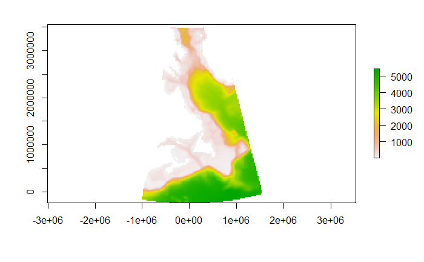

```r
plot(bathyrast)
```

now extract and add to data_aea

|  | cell_id | year | month | depthlayerno | id | decimalLatitude | decimalLongitude | datecollected | institutioncode | individualcount | depth | resname | originalscientificname | collectioncode | day | occurrence | nafo_zone | gear | longitude_meters | latitude_meters | amo_sample | amo_prev | amo_winter | depth_layer | bottom_depth | total_cell_obs | yymm_cell_obs | chl_surface | chl_depth | … |
| --- | --- | --- | --- | --- | --- | --- | --- | --- | --- | --- | --- | --- | --- | --- | --- | --- | --- | --- | --- | --- | --- | --- | --- | --- | --- | --- | --- | --- | --- | --- |
| 1 | 1028 | 2007 | 10 | 34 | 386276184 | 61.882 | -68.600 | 2007-10-18 12:00:00+02 | DFOCENARC | xx | 262 | DFO Central and Arctic Multi-species Stock Assessment Surveys | Mallotus villosus | DFOSurvey_Modified Cosmos 2600 | 18 | 1 | HudsonStrait | bottom_trawl_cosmos_2600 | -444296.6 | 2460623 | 0.158 | 0.098 | 0.138 | 271.3564 | -269 | 1 | 1 | 0.5590227 | NA | … |
| 2 | 1029 | 2007 | 10 | 31 | 386276145 | 61.999 | -68.468 | 2007-10-18 12:00:00+02 | DFOCENARC | xx | 209 | DFO Central and Arctic Multi-species Stock Assessment Surveys | Mallotus villosus | DFOSurvey_Modified Cosmos 2600 | 18 | 1 | HudsonStrait | bottom_trawl_cosmos_2600 | -435849.1 | 2472891 | 0.158 | 0.098 | 0.138 | 199.7900 | -198 | 1 | 1 | 0.6236078 | 0.04989861 | … |
| 3 | 1030 | 2007 | 10 | 28 | 386276062 | 61.977 | -67.569 | 2007-10-17 12:00:00+02 | DFOCENARC | xx | 152 | DFO Central and Arctic Multi-species Stock Assessment Surveys | Mallotus villosus | DFOSurvey_Modified Cosmos 2600 | 17 | 1 | HudsonStrait | bottom_trawl_cosmos_2600 | -390065.1 | 2464892 | 0.158 | 0.098 | 0.138 | 147.4062 | -179 | 2 | 1 | 0.6505818 | 0.09880352 | … |
| 4 | 1030 | 2014 | 8 | 30 | 386263391 | 61.953 | -67.657 | 2014-08-30 12:00:00+02 | DFOCENARC | xx | 175 | DFO Central and Arctic Multi-species Stock Assessment Surveys | Mallotus villosus | DFOSurvey_Modified Modified (21") Campelen | 30 | 1 | HudsonStrait | bottom_trawl_campelen_21 | -394889.5 | 2462708 | 0.335 | 0.222 | 0.128 | 180.5499 | -182 | 2 | 1 | 0.2168258 | 0.07601523 | … |
| 5 | 1035 | 2011 | 8 | 33 | 386247163 | 62.045 | -64.171 | 2011-08-19 12:00:00+02 | DFOCENARC | xx | 244 | DFO Central and Arctic Multi-species Stock Assessment Surveys | Mallotus villosus | DFOSurvey_Modified Modified (21") Campelen | 19 | 1 | 0B | bottom_trawl_campelen_21 | -214790.3 | 2457259 | 0.147 | 0.092 | 0.100 | 244.8906 | -231 | 1 | 1 | 0.3032110 | 0.05210002 | … |
| 6 | 1039 | 2014 | 10 | 39 | 386301912 | 62.053 | -62.296 | 2014-10-14 12:00:00+02 | DFOCENARC | xx | 443 | DFO Central and Arctic Multi-species Stock Assessment Surveys | Mallotus villosus | DFOSurvey_Modified Alfredo-03 | 14 | 1 | 0B | bottom_trawl_alfredo_03 | -118257.1 | 2453515 | 0.292 | 0.310 | 0.128 | 457.6256 | -430 | 1 | 1 | 0.6282594 | 0.02792203 | … |

# remove any duplicate entries

Check to see how many cells have >1 point per timeslice. This needs to be timesliced and 3D

```r
data_aea$cell_id_3d <- paste(data_aea$cell_id, data_aea$depthlayerno, sep="_") #create a new column that is a unique cell_id & depth ID.
head(data_aea)
```

|  | cell_id | year | month | depthlayerno | id | decimalLatitude | decimalLongitude | datecollected | institutioncode | individualcount | depth | resname | originalscientificname | collectioncode | day | occurrence | nafo_zone | gear | longitude_meters | latitude_meters | amo_sample | amo_prev | amo_winter | depth_layer | bottom_depth | total_cell_obs | yymm_cell_obs | chl_surface | chl_depth | … |
| --- | --- | --- | --- | --- | --- | --- | --- | --- | --- | --- | --- | --- | --- | --- | --- | --- | --- | --- | --- | --- | --- | --- | --- | --- | --- | --- | --- | --- | --- | --- |
| 1 | 1028 | 2007 | 10 | 34 | 386276184 | 61.882 | -68.600 | 2007-10-18 12:00:00+02 | DFOCENARC | xx | 262 | DFO Central and Arctic Multi-species Stock Assessment Surveys | Mallotus villosus | DFOSurvey_Modified Cosmos 2600 | 18 | 1 | HudsonStrait | bottom_trawl_cosmos_2600 | -444296.6 | 2460623 | 0.158 | 0.098 | 0.138 | 271.3564 | -269 | 1 | 1 | 0.5590227 | NA | … |
| 2 | 1029 | 2007 | 10 | 31 | 386276145 | 61.999 | -68.468 | 2007-10-18 12:00:00+02 | DFOCENARC | xx | 209 | DFO Central and Arctic Multi-species Stock Assessment Surveys | Mallotus villosus | DFOSurvey_Modified Cosmos 2600 | 18 | 1 | HudsonStrait | bottom_trawl_cosmos_2600 | -435849.1 | 2472891 | 0.158 | 0.098 | 0.138 | 199.7900 | -198 | 1 | 1 | 0.6236078 | 0.04989861 | … |
| 3 | 1030 | 2007 | 10 | 28 | 386276062 | 61.977 | -67.569 | 2007-10-17 12:00:00+02 | DFOCENARC | xx | 152 | DFO Central and Arctic Multi-species Stock Assessment Surveys | Mallotus villosus | DFOSurvey_Modified Cosmos 2600 | 17 | 1 | HudsonStrait | bottom_trawl_cosmos_2600 | -390065.1 | 2464892 | 0.158 | 0.098 | 0.138 | 147.4062 | -179 | 2 | 1 | 0.6505818 | 0.09880352 | … |
| 4 | 1030 | 2014 | 8 | 30 | 386263391 | 61.953 | -67.657 | 2014-08-30 12:00:00+02 | DFOCENARC | xx | 175 | DFO Central and Arctic Multi-species Stock Assessment Surveys | Mallotus villosus | DFOSurvey_Modified Modified (21") Campelen | 30 | 1 | HudsonStrait | bottom_trawl_campelen_21 | -394889.5 | 2462708 | 0.335 | 0.222 | 0.128 | 180.5499 | -182 | 2 | 1 | 0.2168258 | 0.07601523 | … |
| 5 | 1035 | 2011 | 8 | 33 | 386247163 | 62.045 | -64.171 | 2011-08-19 12:00:00+02 | DFOCENARC | xx | 244 | DFO Central and Arctic Multi-species Stock Assessment Surveys | Mallotus villosus | DFOSurvey_Modified Modified (21") Campelen | 19 | 1 | 0B | bottom_trawl_campelen_21 | -214790.3 | 2457259 | 0.147 | 0.092 | 0.100 | 244.8906 | -231 | 1 | 1 | 0.3032110 | 0.05210002 | … |
| 6 | 1039 | 2014 | 10 | 39 | 386301912 | 62.053 | -62.296 | 2014-10-14 12:00:00+02 | DFOCENARC | xx | 443 | DFO Central and Arctic Multi-species Stock Assessment Surveys | Mallotus villosus | DFOSurvey_Modified Alfredo-03 | 14 | 1 | 0B | bottom_trawl_alfredo_03 | -118257.1 | 2453515 | 0.292 | 0.310 | 0.128 | 457.6256 | -430 | 1 | 1 | 0.6282594 | 0.02792203 | … |

and now do one with a timeslice label

```r
data_aea$cell_id_xyzt <- paste(data_aea$cell_id_3d, data_aea$year, data_aea$month, sep="_") #create a new column that is a unique cell_id & depth ID.
head(data_aea)
```

|  | cell_id | year | month | depthlayerno | id | decimalLatitude | decimalLongitude | datecollected | institutioncode | individualcount | depth | resname | originalscientificname | collectioncode | day | occurrence | nafo_zone | gear | longitude_meters | latitude_meters | amo_sample | amo_prev | amo_winter | depth_layer | bottom_depth | total_cell_obs | yymm_cell_obs | chl_surface | chl_depth | … |
| --- | --- | --- | --- | --- | --- | --- | --- | --- | --- | --- | --- | --- | --- | --- | --- | --- | --- | --- | --- | --- | --- | --- | --- | --- | --- | --- | --- | --- | --- | --- |
| 1 | 1028 | 2007 | 10 | 34 | 386276184 | 61.882 | -68.600 | 2007-10-18 12:00:00+02 | DFOCENARC | xx | 262 | DFO Central and Arctic Multi-species Stock Assessment Surveys | Mallotus villosus | DFOSurvey_Modified Cosmos 2600 | 18 | 1 | HudsonStrait | bottom_trawl_cosmos_2600 | -444296.6 | 2460623 | 0.158 | 0.098 | 0.138 | 271.3564 | -269 | 1 | 1 | 0.5590227 | NA | … |
| 2 | 1029 | 2007 | 10 | 31 | 386276145 | 61.999 | -68.468 | 2007-10-18 12:00:00+02 | DFOCENARC | xx | 209 | DFO Central and Arctic Multi-species Stock Assessment Surveys | Mallotus villosus | DFOSurvey_Modified Cosmos 2600 | 18 | 1 | HudsonStrait | bottom_trawl_cosmos_2600 | -435849.1 | 2472891 | 0.158 | 0.098 | 0.138 | 199.7900 | -198 | 1 | 1 | 0.6236078 | 0.04989861 | … |
| 3 | 1030 | 2007 | 10 | 28 | 386276062 | 61.977 | -67.569 | 2007-10-17 12:00:00+02 | DFOCENARC | xx | 152 | DFO Central and Arctic Multi-species Stock Assessment Surveys | Mallotus villosus | DFOSurvey_Modified Cosmos 2600 | 17 | 1 | HudsonStrait | bottom_trawl_cosmos_2600 | -390065.1 | 2464892 | 0.158 | 0.098 | 0.138 | 147.4062 | -179 | 2 | 1 | 0.6505818 | 0.09880352 | … |
| 4 | 1030 | 2014 | 8 | 30 | 386263391 | 61.953 | -67.657 | 2014-08-30 12:00:00+02 | DFOCENARC | xx | 175 | DFO Central and Arctic Multi-species Stock Assessment Surveys | Mallotus villosus | DFOSurvey_Modified Modified (21") Campelen | 30 | 1 | HudsonStrait | bottom_trawl_campelen_21 | -394889.5 | 2462708 | 0.335 | 0.222 | 0.128 | 180.5499 | -182 | 2 | 1 | 0.2168258 | 0.07601523 | … |
| 5 | 1035 | 2011 | 8 | 33 | 386247163 | 62.045 | -64.171 | 2011-08-19 12:00:00+02 | DFOCENARC | xx | 244 | DFO Central and Arctic Multi-species Stock Assessment Surveys | Mallotus villosus | DFOSurvey_Modified Modified (21") Campelen | 19 | 1 | 0B | bottom_trawl_campelen_21 | -214790.3 | 2457259 | 0.147 | 0.092 | 0.100 | 244.8906 | -231 | 1 | 1 | 0.3032110 | 0.05210002 | … |
| 6 | 1039 | 2014 | 10 | 39 | 386301912 | 62.053 | -62.296 | 2014-10-14 12:00:00+02 | DFOCENARC | xx | 443 | DFO Central and Arctic Multi-species Stock Assessment Surveys | Mallotus villosus | DFOSurvey_Modified Alfredo-03 | 14 | 1 | 0B | bottom_trawl_alfredo_03 | -118257.1 | 2453515 | 0.292 | 0.310 | 0.128 | 457.6256 | -430 | 1 | 1 | 0.6282594 | 0.02792203 | … |

```r
write.csv(data_aea, "../output/bio/presence_points_without_envdata_relooped_glbathy_cellid_xyzt.csv", row.names = FALSE)
```

ok lets see how many have more than one obs per cell

```r
unique_pointpercell <- unique(data_aea$total_cell_obs_xyzt)
unique_pointpercell
```

```
[1]  1  3  2  4  5  6 15
```

bugger… ok so lets do a frequency table

| total_cell_obs_xyzt | freq | no_cells |
| --- | --- | --- |
| 2 | 1676 | 838 |
| 3 | 279 | 93 |
| 4 | 56 | 14 |
| 5 | 10 | 2 |
| 6 | 6 | 1 |
| 15 | 15 | 1 |

so there are 949 3d timesliced cells that contain more than one occurrence, and 2042 rows. - different sampling days - different coordinates - risk of duplicate entries (but only if two instituions inputted the same data with slightly different coordinates and different reserch program names - see cell3985_18_2000_7 below as example)

Ideally you only want one observation cell cell_id_xyzt. First see if any are missing depth data

find the column numbers that correspond to the env. data (use fastmatch package as is quicker)

```r
fmatch("chl_surface", names(celobsmore1)) #28
```

```
[1] 28
```

```r
fmatch("chl_depth", names(celobsmore1)) #29
```

```
[1] 29
```

```r
fmatch("mlp_surface", names(celobsmore1)) #30
```

```
[1] 30
```

```r
fmatch("o2_surface", names(celobsmore1)) #31
```

```
[1] 31
```

```r
fmatch("o2_depth", names(celobsmore1)) #32
```

```
[1] 32
```

```r
fmatch("salinity_surface", names(celobsmore1)) #33
```

```
[1] 33
```

```r
fmatch("salinity_depth", names(celobsmore1)) #34
```

```
[1] 34
```

```r
fmatch("ssh_surface", names(celobsmore1)) #35
```

```
[1] 35
```

```r
fmatch("temp_surface", names(celobsmore1)) #36
```

```
[1] 36
```

```r
fmatch("temp_depth", names(celobsmore1)) #37
```

```
[1] 37
```

then subset any with NA values

```r
celobsmore1_novals <-  celobsmore1[!complete.cases(celobsmore1[28:37]), ] #28:37 represent the columns w/ env. data
nrow(celobsmore1_novals) #just to check how many there are - 1095 out of 2042
```

```
[1] 1095
```

ok and subset with all values

```r
celobsmore1_allvals <- celobsmore1[complete.cases(celobsmore1[28:37]), ] #28:37 represent the columns w/ env. data
nrow(celobsmore1_allvals) #947 out of 2042
```

```
[1] 947
```

ok so how many unique cells do we have with complete data…

```r
pointpercellcount_alldata <- count(celobsmore1_allvals, "total_cell_obs_xyzt")
pointpercellcount_alldata$no_cells <- pointpercellcount_alldata$freq / pointpercellcount_alldata$total_cell_obs_xyzt
write.csv(pointpercellcount_alldata, file = "../output/bio/pointpercellcount_alldata.csv")
pointpercellcount_alldata
```

[output not shown]

and see which cell_id_xyzt appear in both celobsmore1_allvals and celobsmore1_novals

```r
celobsmore1_allnovals <- inner_join(celobsmore1_allvals, celobsmore1_novals)
celobsmore1_allnovals
```

None…. which is good. I’d expect observations in the same xyzt to have the same values

so, I can successfully reduce the observations down to one per xyzt

```r
data_aea <- rbind(presabnodup, duplicatesbegone)
nrow(data_aea) #1550300 - great!
```

```
[1] 10300
```

# recalculate the total_cell_obs_xyzt column

|  | cell_id | year | month | depthlayerno | id | decimalLatitude | decimalLongitude | datecollected | institutioncode | individualcount | depth | resname | originalscientificname | collectioncode | day | occurrence | nafo_zone | gear | longitude_meters | latitude_meters | amo_sample | amo_prev | amo_winter | depth_layer | bottom_depth | total_cell_obs | yymm_cell_obs | chl_surface | chl_depth | … |
| --- | --- | --- | --- | --- | --- | --- | --- | --- | --- | --- | --- | --- | --- | --- | --- | --- | --- | --- | --- | --- | --- | --- | --- | --- | --- | --- | --- | --- | --- | --- |
| 1 | 1028 | 2007 | 10 | 34 | 386276184 | 61.882 | -68.600 | 2007-10-18 12:00:00+02 | DFOCENARC | xx | 262 | DFO Central and Arctic Multi-species Stock Assessment Surveys | Mallotus villosus | DFOSurvey_Modified Cosmos 2600 | 18 | 1 | HudsonStrait | bottom_trawl_cosmos_2600 | -444296.6 | 2460623 | 0.158 | 0.098 | 0.138 | 271.3564 | -269 | 1 | 1 | 0.5590227 | NA | … |
| 2 | 1029 | 2007 | 10 | 31 | 386276145 | 61.999 | -68.468 | 2007-10-18 12:00:00+02 | DFOCENARC | xx | 209 | DFO Central and Arctic Multi-species Stock Assessment Surveys | Mallotus villosus | DFOSurvey_Modified Cosmos 2600 | 18 | 1 | HudsonStrait | bottom_trawl_cosmos_2600 | -435849.1 | 2472891 | 0.158 | 0.098 | 0.138 | 199.7900 | -198 | 1 | 1 | 0.6236078 | 0.04989861 | … |
| 3 | 1030 | 2007 | 10 | 28 | 386276062 | 61.977 | -67.569 | 2007-10-17 12:00:00+02 | DFOCENARC | xx | 152 | DFO Central and Arctic Multi-species Stock Assessment Surveys | Mallotus villosus | DFOSurvey_Modified Cosmos 2600 | 17 | 1 | HudsonStrait | bottom_trawl_cosmos_2600 | -390065.1 | 2464892 | 0.158 | 0.098 | 0.138 | 147.4062 | -179 | 2 | 1 | 0.6505818 | 0.09880352 | … |
| 4 | 1030 | 2014 | 8 | 30 | 386263391 | 61.953 | -67.657 | 2014-08-30 12:00:00+02 | DFOCENARC | xx | 175 | DFO Central and Arctic Multi-species Stock Assessment Surveys | Mallotus villosus | DFOSurvey_Modified Modified (21") Campelen | 30 | 1 | HudsonStrait | bottom_trawl_campelen_21 | -394889.5 | 2462708 | 0.335 | 0.222 | 0.128 | 180.5499 | -182 | 2 | 1 | 0.2168258 | 0.07601523 | … |
| 5 | 1035 | 2011 | 8 | 33 | 386247163 | 62.045 | -64.171 | 2011-08-19 12:00:00+02 | DFOCENARC | xx | 244 | DFO Central and Arctic Multi-species Stock Assessment Surveys | Mallotus villosus | DFOSurvey_Modified Modified (21") Campelen | 19 | 1 | 0B | bottom_trawl_campelen_21 | -214790.3 | 2457259 | 0.147 | 0.092 | 0.100 | 244.8906 | -231 | 1 | 1 | 0.3032110 | 0.05210002 | … |
| 6 | 1039 | 2014 | 10 | 39 | 386301912 | 62.053 | -62.296 | 2014-10-14 12:00:00+02 | DFOCENARC | xx | 443 | DFO Central and Arctic Multi-species Stock Assessment Surveys | Mallotus villosus | DFOSurvey_Modified Alfredo-03 | 14 | 1 | 0B | bottom_trawl_alfredo_03 | -118257.1 | 2453515 | 0.292 | 0.310 | 0.128 | 457.6256 | -430 | 1 | 1 | 0.6282594 | 0.02792203 | … |

check for unique values(should be 1 only)

```r
unique_pointpercell <- unique(data_aea$total_cell_obs_xyzt)
unique_pointpercell
```

```
[1] 1
```

Great! Save

```r
write.csv(data_aea, file = "../output/bio/presence_points_without_envdata_relooped_glbathy_nodup.csv", row.names = FALSE) # change the path to where ever you would like to save it
```